# STÆ529M Homework 7

Kári Hlynsson

## Packages

```r
library(rjags)
library(knitr)
library(latex2exp)
```

## Exercise 1

Fit model $\mathcal M_2$ to the `airquality` data from the previous problem, and use posterior predictive checks to verify that the model fits well. If you find model misspecification, suggest (but do not fit) alternatives.

### Solution

The models are

$$\begin{align*}
&\mathcal M_1 : \mathrm{(ozone)}_i \sim
\mathrm{Normal}\big(\beta_1 + \beta_2 (\mathrm{solar.R})_i,
\sigma^2\big) \\
&\mathcal M_2: \mathrm{(ozone)}_i \sim
\mathrm{Normal}\big(\beta_1 + \beta_2 \mathrm{(solar.R)}_i + \beta_3
\mathrm{(temp)}_i + \beta_4 \mathrm{(wind)}_i, \sigma^2\big).
\end{align*}$$

I changed the coefficients in front of the covariates since there seems to be a typo in the exercise and the authors put $\beta_2$ on both covariates but treat them as separate coefficients in the solution to exercise 1.

Load the data set and and set up the model matrix $\mathbf X_2$:

```r
data(airquality)
```

Model matrix and setup:

```r
Y <- airquality$Ozone

solar <- scale(airquality$Solar.R)
temp  <- scale(airquality$Temp)
wind  <- scale(airquality$Wind)

X           <- cbind(1, solar, temp, wind)
colnames(X) <- c("(Intercept)", "solar", "temp", "wind")

miss_mask <- is.na(Y + rowSums(X))

X <- X[!miss_mask,]
Y <- Y[!miss_mask]

n <- nrow(X)
p <- ncol(X)

data <- list(X = X, Y = Y, n = n, p = p)
```

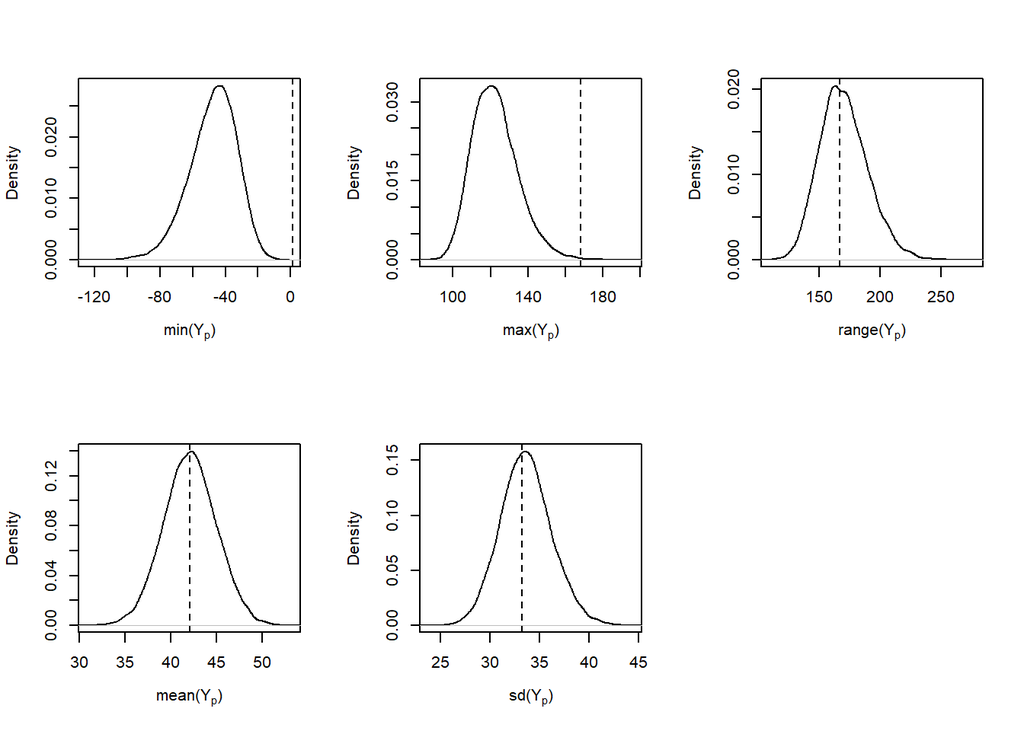

```r
init_airq <- textConnection("model{
  for (i in 1:n) {
    Y[i] ~ dnorm(inprod(X[i,], beta), tau)
  }

  for (j in 1:p) {
    beta[j] ~ dnorm(0, 0.0001)
  }

  tau ~ dgamma(0.1, 0.1)

  for (i in 1:n) {
    Yp[i] ~ dnorm(inprod(X[i,], beta), tau)
  }

  D[1] <- min(Yp)
  D[2] <- max(Yp)
  D[3] <- max(Yp) - min(Yp)
  D[4] <- mean(Yp)
  D[5] <- sd(Yp)
}")

model_airq <- jags.model(init_airq, data = data, n.chains = 2,
                         quiet = TRUE)

update(model_airq, n.iter = 1e+4, progress.bar = "none")

samples_airq <- coda.samples(model_airq, variable.names = c("beta", "D", "Yp"),
                             n.iter = 2e+4, progress.bar = "none")

sum_airq <- summary(samples_airq)

D2 <- samples_airq[[1]][,paste0("D[", 1:5, "]")]
D0 <- c(min(Y), max(Y), max(Y) - min(Y), mean(Y), sd(Y))
ss_names <- c("min", "max", "range", "mean", "sd")
pvals <- rep(0, 5); names(pvals) <- ss_names

library(latex2exp)

par(mfrow = c(2,3))
for (i in 1:5) {
  plot(density(D2[,i]), xlim = range(D2[,i], D0[i]),
       main = NA, xlab = TeX(paste0(ss_names[i], "($Y_p$)")))
  abline(v = D0[i], lty = 2)

  pvals[i] <- mean(D2[,i] > D0[i])
}
```

Let’s take a look at the $p$-values:

```r
pvals
```

```
##     min     max   range    mean      sd
## 0.00000 0.00205 0.53440 0.50020 0.54880
```

The minimum and maximum are near zero, indicating that the model does not fit the scale of the data well. However, the range, mean and standard deviation fit well, indicating that while the model may not be problematic, scaling the data and/or treating outliers might help. Below is a plot that shows the observed values against the fitted ones:

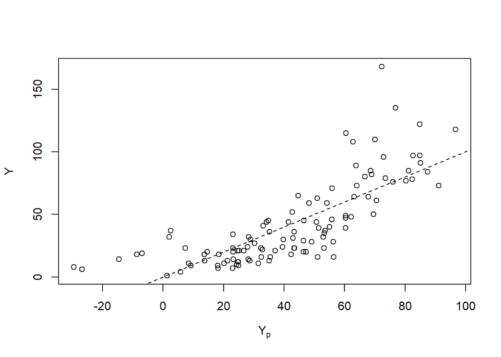

```r
Yp <- sum_airq$statistics[paste0("Yp[", 1:111, "]"), 1]

# normal model
lin <- lm(Y ~ X[,-1])

plot(Yp, Y, xlab = TeX("$Y_p$"))
abline(a = 0, b = 1, lty = 2)
```

It seems the model underfits the data at the extremes. This may because of the scale of the reponse, shown in the below histogram:

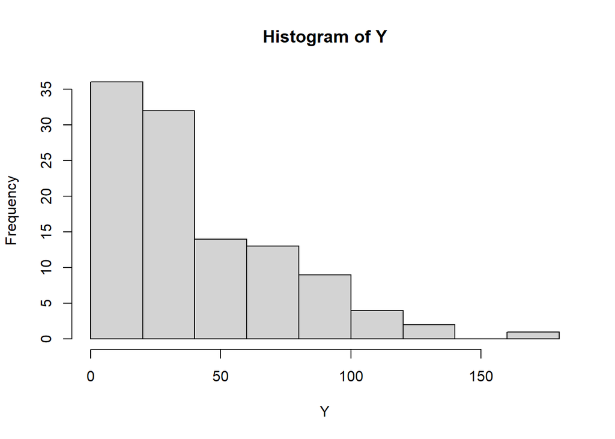

```r
hist(Y)
```

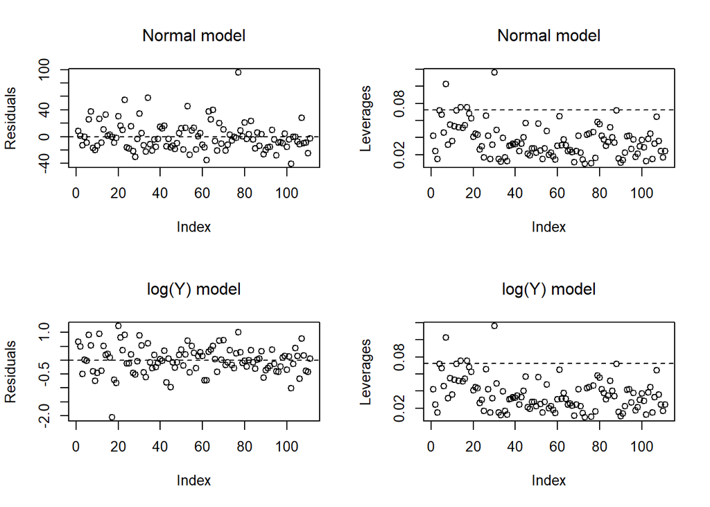

```r
# residual plots for normal model
par(mfrow = c(2, 2), font.main = 1)
plot(lin$resid, ylab = "Residuals", main = "Normal model")
abline(h = 0, lty = 2)
plot(hat(X), ylab = "Leverages", main = "Normal model")
abline(h = 2 * p / n, lty = 2)

# linear model with log-transformed response
lin <- lm(log(Y) ~ X[,-1])
pred_lin <- predict(lin, data.frame(X[,-1]))

# plot the residuals
plot(lin$resid, ylab = "Residuals", main = "log(Y) model")
abline(h = 0, lty = 2)
plot(hat(X), ylab = "Leverages", main = "log(Y) model")
abline(h = 2 * p / n, lty = 2)
```

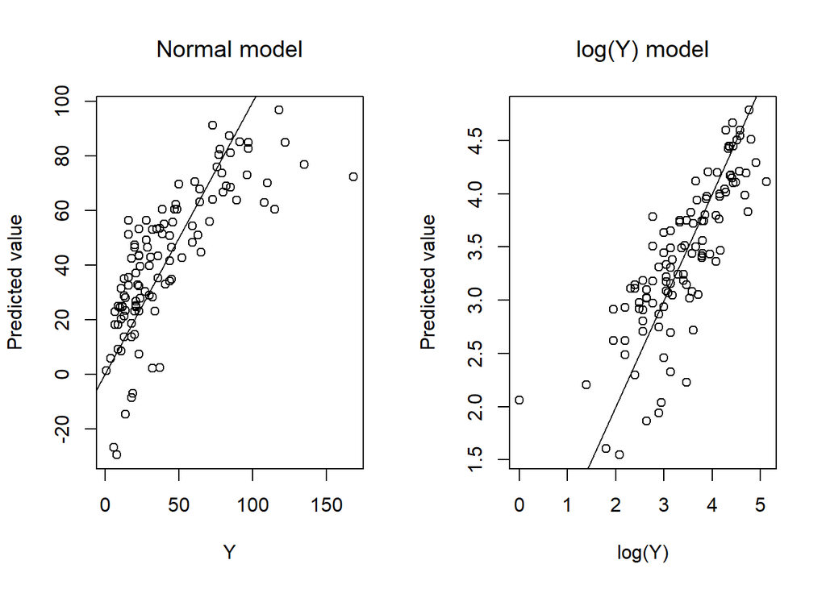

```r
par(mfrow = c(1, 2), font.main = 1)
plot(Y, Yp, xlab = "Y", ylab = "Predicted value", main = "Normal model")
abline(a = 0, b = 1)
plot(log(Y), pred_lin, xlab = "log(Y)", ylab = "Predicted value", main = "log(Y) model")
abline(a = 0, b = 1)
```

The transformation seemingly diminishes the discrepancy between the fitted and observed data. The largest residual in the $\log(Y)$ model is due to the data point being equal to one, and thus $\log(Y) = 0$ which ends up far from the other observations.

## Exercise 2

We use the ‘’Mr October’’ data (Section 2.4) $Y_1 = 563$, $N_1 = 2820$, $Y_2 = 10$ and $N_2 = 27$. Compare the two models

$$\begin{align*}
&\mathcal M_1: Y_1 | \lambda_1 \sim
\mathrm{Poisson}(N_1\lambda_1) \quad \text{and} \quad Y_2 | \lambda_2
\sim \mathrm{Poisson}(N_2\lambda_2) \\
&\mathcal M_2: Y_1 | \lambda_0 \sim
\mathrm{Poisson}(N_1\lambda_0) \quad \text{and} \quad Y_2 | \lambda_0
\sim \mathrm{Poisson}(N_2\lambda_0)
\end{align*}$$

using Bayes factors, DIC and WAIC. Assume the $\mathrm{Uniform}(0, c)$ prior for all $\lambda_j$ and compare the results for $c = 1$ and $c = 10$.

### Solution

To recap briefly, the data are the total number of games played and number of home runs in regular-season games as well as world series for the American baseball player Reggie Jackson (“Mr. October”).

We denote by $Y_1$ and $N_1$ the number of home runs and total number of games in the regular season. World series data are analogously labelled $Y_2$ and $N_2$. In this exercise, we are competing two models $\mathcal{M}_1$ and $\mathcal{M}_2$, where the first model claims that the rate of home runs is different when the player is competing in the World Series or Regular-Season. The latter model claims that there is no difference. Since we will be repeating the same analyses quite a bit, it is convenient to declare a function which automates this process.

```r
# Mr. October data
N <- c(2820, 27)
Y <- c(563,  10)

# Model parameters
p  <- 2
n  <- 2

# Model strings
str_october_1 <- "model{
  for (i in 1:n) {
    Y[i]     ~ dpois(N[i] * lambda[i])
    like[i] <- dpois(Y[i], N[i] * lambda[i])
  }

  for (j in 1:p) { lambda[j] ~ dunif(0, c) }
}"

str_october_2 <- "model{
  for (i in 1:n) {
    Y[i]     ~ dpois(N[i] * lambda)
    like[i] <- dpois(Y[i], N[i] * lambda)
  }

  lambda ~ dunif(0, c)
}"

models_october <- c(str_october_1, str_october_2)

# Custom print function for information criterion
print_ic <- function(IC, P) {
  if(class(IC) == "mcarray") {
    IC <- sum(IC)
    P  <- sum(P)
  }
  cat(paste("- Mean deviance     :", signif(IC, 3), "\n"))
  cat(paste("- Penalty           :", signif(P, 3), "\n"))
  cat(paste("- Penalised deviance:", signif(IC + P, 3), "\n"))
}

# Automates modelling process
mcmc_october <- function(model_no, c, params) {
  init_october <- textConnection(models_october[model_no])

  data <- list(N = N, Y = Y, c = c, n = n, p = p)
  if (model_no == 2) data <- data[-5]

  model_october <- jags.model(init_october, data = data,
                              n.chains = 2, quiet = TRUE)

  update(model_october, n.iter = 1e+4, progress.bar = "none")

  DIC     <- dic.samples(model_october, n.iter = 5e+4, progress.bar = "none")

  samples <- coda.samples(model_october, variable.names = c("like"),
                          n.iter = 2e+4, progress.bar = "none")


  like  <- rbind(samples[[1]], samples[[2]])
  L_bar <- colMeans(like)

  Pw <- sum(apply(log(like), 2, var))
  WAIC <- -2 * sum(log(L_bar)) + 2 * Pw

  cat(paste0("MODEL: ", model_no, ", C: ", c, "\n"))
  cat("==========================\n")
  cat("WAIC\n")
  print_ic(WAIC, Pw)
  cat("\n")
  cat("DIC\n")
  print_ic(DIC$deviance, DIC$penalty)
  cat("==========================\n\n")
}
```

Running the above function for the models $\mathcal{M}_1$ and $\mathcal{M}_2$ with $c = 1$ yields the result shown below:

```r
mcmc_october(model_no = 1, c = 1)
```

```
## MODEL: 1, C: 1
## ==========================
## WAIC
## - Mean deviance     : 15.7
## - Penalty           : 1.01
## - Penalised deviance: 16.7
##
## DIC
## - Mean deviance     : 14.3
## - Penalty           : 2
## - Penalised deviance: 16.3
## ==========================
```

```r
mcmc_october(model_no = 2, c = 1)
```

```
## MODEL: 2, C: 1
## ==========================
## WAIC
## - Mean deviance     : 17.2
## - Penalty           : 0.566
## - Penalised deviance: 17.8
##
## DIC
## - Mean deviance     : 16.4
## - Penalty           : 0.995
## - Penalised deviance: 17.4
## ==========================
```

Judging from the above output $\mathcal{M}_1$ seems to be the preferable model, since both the $\textit{DIC}$ and $\textit{WAIC}$ agree.